**CSE2215** - Computer Graphics

Elmar Eisemann, Martin Skrodzki, Michael Weinmann, Ricardo Marroqium

# Shading

In this assignment, you will learn about light surface interaction. The first part will concentrate on the concepts behind various shading models (which define the appearance of an object’s surface), while the second part will guide you to reflect (pun intended…) on light-surface configurations to achieve certain targets. You will learn about Lambertian, Phong, and Blinn-Phong shading models and much more…

In modern graphics pipelines, we would write shaders, which are small programs to define these shading models efficiently. They are typically executed on the GPU (graphics processing unit a.k.a. graphics card). Today, however, we will work in a simulated framework that will enable us to use these shaders on the CPU, which also facilitates debugging. The functions you will implement are called for each vertex of the model, and the resulting color will be mapped to these vertices. There are many comments in the code to help you along, so read these carefully. If you are asked to find an optimal solution, it is expected that you derive the mathematically accurate solution and build your code based on this result.

### Rules

For this assignment, the following rules apply:

**General**

- We strongly recommend to do the assignment **individually**.
- This practical will help you prepare for the programming exam.
- We ask you to give the practical a try yourself to see whether you can solve it. Remember that the programming exam will also be an individual assessment.
- As always, you can approach the TAs with questions during the lab sessions.
- Your should compile your code **on Windows with Visual Studio 2022** (using the default MSVC toolchain). Otherwise, the TAs might not be able to help you with related issues.
- Submission on Brightspace is not required for this practical.

**Evaluation**

- This practical is ungraded.
- We provide you with a unit test framework using the [Catch2](https://github.com/catchorg/Catch2/) under `tests` for you to self-test your solutions.
- To use the test framework, select and build the target `Bachelor_Practical3Tests`
- You may add your own tests in ‘tests/your_tests.cpp’ and run them via the target `Bachelor_Practical3YourTests`
- If it prints “xxx failed”, it means some of your solutions are incorrect. See the error messages in the console for a detailed explanation.
- If it prints “All tests passed”, you are good to go!

## General remarks

Use the user interface (GUI) to change the light color using the color picker.

The implementation of the following exercises should go in `src/your_code_here.h`. Properties of the material are passed in the `MaterialInformation` struct which is defined in `src/common.h`. Beware that you don’t want to change anything other than potentially values here or the unit tests might brake.

> **Note on back-faces.** You will notice that triangles seen from behind might appear illuminated if the light is in the front. You can ignore this case. Yet, you **do** need to properly handle the case of a light being behind the surface. Some models may have holes that light can pass through; you do not need to fix these.

It could be a good idea to make a value table by hand, as the one shown below:

| Vertex | Light | Camera | Kd | Ks | Shininess | Light Colour | Result |
| --- | --- | --- | --- | --- | --- | --- | --- |
| (0,0,0) | (0,2,0) | (0,1,0) | (1,1,1) | (0,0,0) | 0 | (1,1,1) | … |
| (0,0,0) | (0,1,1) | (0,1,0) | (1,1,1) | (0,0,0) | 0 | (1,1,1) | … |
| (2,2,0) | (4,4,0) | (2,3,1) | (0.8,0.4,0.2) | (0.2,0.4,0.6) | 3 | (1,1,1) | … |
| … | … | … | … | … | … | … | … |

Make sure that the results make sense to you. We provide example scenarios but we recommend you to come up with some test cases on your own as well. If your solution is far off, many results will differ; if you are close the perfect answer, most of the table results should coincide with your code output.

## Barbie’s dream car

In this section, you will implement various illumination models. We will apply them to simulate the appearance of a car - actually, Barbie’s dream car. As you might know, Barbie likes pink and what could be more exciting than producing a pink material for her car?

### 1. Lambertian model

We first define a simple diffuse surface shading. The basic formula for the *Lambertian Diffuse Component* is:
$$D = I K_d \cos(\theta),$$
where $\theta \in [-\pi/2, \pi/2]$ is the angle between the normal $N$ and the direction $L$ from the vertex to the light, $I$ is the color of the incident light in RGB, $K_d$ is the diffuse surface color in RGB. To make the car appear as intended, we can define $K_d$ as the RGB value $(0.9, 0.25, 0.6)$, matching Barbie’s pink. For this diffuse model, you can calculate the cosine of the angle between two vectors efficiently - please refer to the linear algebra lecture for a refresher if needed. Finally, make sure any light coming from behind the surface results in black $(0,0,0)$.

> **Assignment: implement the Lambertian Model in the `diffuseOnly()` function in `src/your_code_here.h`.**

[figure not shown]

### 2. Material of the car at night

After the previous exercise, Barbie’s car indeed appears beautifully pink under white light. Unfortunately, towards the day’s end, as Barbie is taking a drive around town, the light of the evening sun reaching Barbieland changes to a slightly more reddish tone - namely the RGB value $I=(0.9, 0.7, 0.7)$.

Please define a $K_d$ value for Barbies car, s.t. it looks identical under this new illumination to the original color under white light.

> **Assignment: implement the new car material in the function `getMaterialEveningCar()` in `src/your_code_here.h`.**

Use the arguments passed into this function to solve this problem. To test the material, select the Lambertian diffuse model and push the evening button. To compare to the original car in white light, press the day button. If correctly defined, the two cars should appear identical.

### 3. Phong Model specular component

If we are really honest, so far, Barbie’s car isn’t very flashy. Cars typically have a highly reflective coating - currently, ours is missing specularities. To address this problem, we will implement the *Phong Specular Component*, which introduces view-dependent highlights. The basic formula is:
$$S = I K_s \cos(\phi)^s,$$
where $I$ is the incident light color, $K_s$ is the specular color (in our case, it should be white $(1, 1, 1)$), and $\phi$ is the angle between vectors $R$ and $V$. Here $R$ is defined as a reflection vector (the new direction vector resulting from the light incident to the vertex being reflected at the plane defined by normal $N$), and $V$ is the view direction (from the vertex towards the camera). Finally, $s$ is a shininess exponent, which influences the sharpness of highlights. Be aware: as with the Lambertian, a light placed behind the model should not illuminate it from the front.

> **Assignment: implement the Phong Model in the `phongSpecularOnly()` function in `src/your_code_here.h`**

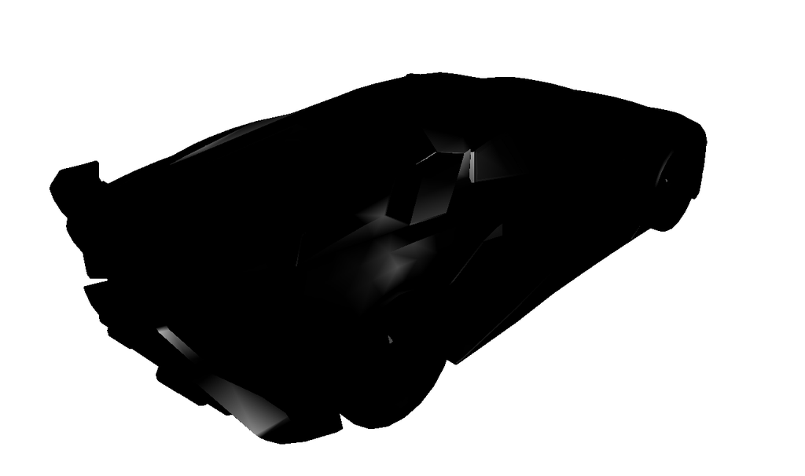

[figure not shown]

### 4. Blinn-Phong Model specular component

Typically, the Blinn-Phong specularity model is slightly more realistic. Its formula is:
$$S = I K_s \cos(\delta)^s,$$
where $\delta$ is the angle between vectors $H$ and $N$. This differs subtly from the Phong model, as $H$ here is a half vector - a *unit* vector lying halfway between the view direction $V$ and the light direction $L$. Again, make sure a light placed behind the model does not illuminate it from the front.

> **Assignment: implement the Blinn-Phong model in the `blinnPhongSpecularOnly()` function in `src/your_code_here.h`**

The material definition gets pretty close to a real pink car coating.

[figure not shown]

[figure not shown]

### 5. Illustrating the differences in specularity models

As indicated, the Blinn-Phong model was shown to be slightly closer to many real-world materials than the Phong model. Let’s examine the differences, and visualize the deviations per model vertex.

For this, we define $d$ as the length of the vector that is defined by the difference between the Phong specular component and the Blinn-Phong specular component. We then compare also the length of the Phong specular component vector and the Blinn-Phong specular component. If the first is larger than the second, we define the output color $C$ by setting $C$’s red channel to $d$ and the other two to $0$. If not, we set the red channel to $0$, and place $d$ in $C$’s green and blue channels. For a better visualization, we multiply the resulting color by $4$.

> **Assignment: implement this difference shading model in the `diffPhongSpecularOnly()` function in `src/your_code_here.h`**

[figure not shown]

As you can see, both specularities differ slightly. At grazing angles, the differences become especially visible.

### 6. Gooch Diffuse Shading

The car material we have produced so far is perfect for a realistic movie. We now want to define a non-photorealistic material that approaches an appearance of a comic book that one could imagine for animated movies.

*Gooch shading* is such a stylized shading model. It builds on the idea that surfaces facing the sun typically appear warmer than surfaces facing away from it, which often exhibit a blueish tint.

Specifically, we will vary the shading following the formula:
$$D = I ((\frac{1+\cos(\theta)}{2}) k_{warm} +
(1-\frac{1+\cos(\theta)}{2}) k_{cool}),$$
where $\cos(\theta)$ is defined as in the first exercise, and the colors $k_{cool}$, $k_{warm}$ are defined below. Please note that, here, surfaces “lit” from behind will not be black and the quantity $\cos(\theta)$ is intended to vary over the interval $[-1,1]$.

The terms $k_{cool}$ and $k_{warm}$ mix the surface colour $k_d$ with a blue/yellow tint respectively:
$$\begin{aligned}
k_{cool} &= k_{blue} + \alpha k_d \\
k_{warm} &= k_{yellow} + \beta k_d,
\end{aligned}$$
where $k_{blue} = (0,0,b)$ and $k_{yellow}=(y,y,0)$. Note that $k_{cool}$ and $k_{warm}$ may fall outside the standard colour range of $[0, 1]$, so you should ensure that the final values are in range. More information on the Gooch shading model can be found in the paper [A Non-Photorealistic Lighting Model For Automatic Technical Illustration by Gooch et al.](https://dl.acm.org/doi/pdf/10.1145/280814.280950). There is a mistake in one of their formulas, can you spot it? To verify a correct implementation, make sure your resulting render is similar to the example below (n=2).

To further transform the appearance into an illustration style, we *discretize* the color values to obtain regions of constant color. To this extent, we will partition the interval of $cos(\theta)$, which is $[-1,1]$, in $2n+1$ subintervals of equal length. We enumerate these intervals from left to right with indices $0$ to $2n$. The color for a $cos(\theta)$ value in interval $i$ is then defined as:
$$D_i = \frac{i}{2n} k_{warm} + (1 - \frac{i}{2n}) \cdot k_{cool}.$$
If this value lands on the boundary between two intervals, either side can be chosen. Remember, to obtain the diffuse illumination, like before, you still have to consider the intensity $I$, as shown by the continuous equation. The resulting appearance is shown below. Feel free to play with the parameters by changing their values at the top of the file.

> **Assignment: implement the discretized Gooch shading model in the `gooch()` function in `src/your_code_here.h`**

[figure not shown]

## Light optimization

Knowledge about light-surface interaction can be very useful in many application contexts. In this part of the exercise, we will investigate a few simplified scenarios to optimize lights or surface orientation to achieve a wanted illumination result.

### 7. Controlling a solar power tower

A solar power tower (heliostat) as depicted in the image below, has mirrors that reflect sunlight towards a central focus, in order to heat molten salt or other substances. Captured energy can be stored in the form of heat or transformed into electricity through a turbine.

In our simplified scenario, we will assume a single mirror and a pole to whose tip we want to redirect sunlight from the mirror center. You are asked, for a given sun direction $L$, a vertex on the mirror’s center $P$, and a position at the pole’s tip $T$, to find a normal $N$, such that the mirror’s center reflects the incoming light $L$ towards position $T$.

[figure not shown]

To solve this problem, we will first define the unit *direction* to which the mirror reflects an incident light ray in the function `computeReflection()`. It receives a normal $N$, describing the mirror’s orientation, and an incomping light direction $L$ towards the mirror.

> **Assignment: implement the function `computeReflection()` in `src/your_code_here.h`.**

Do **not** rely on predefined functions (e.g., `glm::reflect`) but derive the formulas yourself. The application should now show the reflected ray for you. Using the button *change LightPos to camPos*, you can change the light position to the camera position and orientation to try other configurations.

Next, we want to determine the optimal orientation for the mirror, such that light is reflected towards the pole’s tip, in the `optimalMirrorNormal()` function. The input to this function is the mirror center, the incident light direction, and the pole tip. Every time you press the *Optimal Mirror Normal* button, this function is called to generate a new mirror orientation. Make sure to normalize your output normal vector!

> **Assignment: implement the function `optimalMirrorNormal()` in `src/your_code_here.h`.**

### 8. Visualization of shading models

To allow a better understanding of the reflectance behavior of the used material, you will implement basic functions to visualize the shading model based on OpenGL, i.e. we want to illustrate how much light is reflected into all the different directions according to the shading model. In the following, we provide a step-by-step description of how to achieve this. In the framework, there is a respective section with the functions that you have to complete. Note that the functions to draw elements in the scene based on OpenGL will help you to visualize whether your implementation is correct. The unit tests for this exercise check the generation of the information that has to be visualized.

To see the UI for this exercise push “Shading Model Viewer” button from the top of the UI.

Then, start with the generation of a reference geometry in terms of a simple surface patch around a certain point. For this purpose, first draw an axis-aligned quad in the xz-plane centered onto the origin with a size of `2x2` using `GL_QUADS`.

To highlight the patch boundary, also draw the boundary line of the quad by drawing line segments between the respective vertices using `GL_LINES`.

> **Assignment: Implement the visualisation methods `drawSurfacePoint/Patch/Boundary()` in `src/your_code_here.h`**

To get insights on the currently considered light direction with respect to the surface, plot both the surface normal at the considered point, and the light direction as OpenGL-based line segments (i.e., using `GL_LINES`) starting at the considered point and pointing in the respective directions. To visualize the direction of the vectors, mark the tip of the drawn vectors by drawing a small point at the tip of the normal based on `GL_POINTS`.

> **Assignment: Implement the visualisation method `drawVector()` in `src/your_code_here.h`**

Now that you have visualized the light direction and surface normal for the considered surface point, continue with the visualization of the reflectance of the light into different directions according to the shading model. The involved steps are: * Consider spherical coordinates to describe points on a sphere (see Figure below). Accordingly, generate points on a spherical grid (radius considered for the sphere points should be 1) placed around the considered surface point (i.e., the center of the sphere has to coincide with the origin) by sampling the polar angle and the azimuthal angle with a certain resolution that can be set in the interface (the interface part for this is provided in the framework). For efficiency aspects, only define one point at the poles instead of creating multiple coincident points there. We will consider these generated points on the sphere as the samples on the sphere as the directions for which we want to visualize the amount of reflected light. You can plot these points by using `GL_POINTS`.

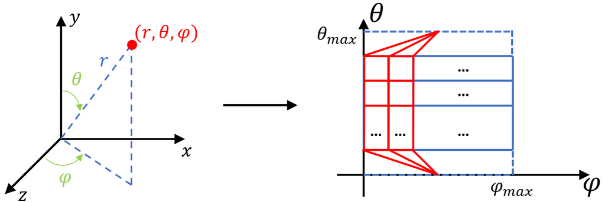

- Use the shading model to compute the light reflected into each of the directions defined by the vertices of the sphere and visualize the light contribution sent into each of these directions. For the latter, apply a radial displacement of the respective vertex of the sphere so that the distance of the vertex to the surface point in the sphere center matches the amount/intensity of the light reflected into that direction.

> **Assignment: Implement the methods `generateSphereVertices()`, `getReflectedLightInputParameters()` and `displaceVerticesByIntensity()` in `src/your_code_here.h`**

Depending on the mode specified by `visualization_mode` (which can be set to `points`, `vectors` and `mesh`), show the following:

1. `points`: Visualize the amount of reflected light in the different directions based on drawing the displaced points and adjusting their color so that it matches the light reflected into the direction defined by the respective vertex.
2. `vectors`: Visualize the amount of reflected light in the different directions based on drawing vectors (i.e., lines starting from the surface point to each of the displaced points) and mark the tips of the vectors by drawing small points with their color adjusted so that it matches the light reflected into the respective direction.
3. `mesh`: Now, generate a smoother visualization of the reflectance behavior by forming a surface mesh of connected, non-overlapping surface elements. For this, you have to use surface patches in terms of both triangles for the surface patches next to poles and quads for the remaining surface patches as shown in the figure above. Note, this figure also illustrates the angular sampling you have to use in this excercise to sample the directions in the theta-phi space used to define the coordinates of the sphere (as mentioned before). This means you have to store the indices of points and define the triangles or quads respectively via the indices of corresponding triplets or quadrupels of points. Then, draw the remaining triangles and quads based on using `GL_TRIANGLES` and `GL_QUADS`.

> **Assignment: Implement the visualisation methods `drawSphereGrid/Vectors/Mesh()` in `src/your_code_here.h`, as well as the method to generate the mesh `generateSphereMesh()`**

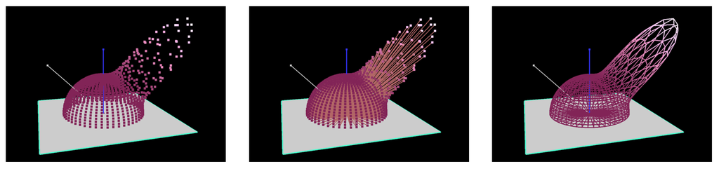